# Paper case study 2: Multi-pathogen system with multivalent vaccinaton (Diphtheria and Pertussis)

# 1.5 Immunity Model

Here, we specify the immunity model which will determine the probability that an exposure event is successful in inducing an immunological response. Since we have both vaccination and natural infection events, we will use immunity_model_vacc_ifxn_biomarker_prot. With this immunity model, the probability of successful vaccination exposure depends on the number of vaccines received prior to time t and the individual’s age at time t while the probability of successful infection is dependent on the biomarker quantity, in this case antibody titer, at the time of exposure. Individuals can have up to 3 successful vaccination events (aka 3 doses) and are eligible for vaccination starting at 2 months of age to align with the diphtheria/pertussis vaccination schedule.

As for the probability of a successful infection, we placed no limit on the maximum number of infections to either diphtheria or pertussis however our selected immunity model will take into account an individual’s current biomarker  
level when determining the probability of a successful infection. Additional successful exposure events aka “reinfection” events are representative of boosting events which can occur if an individual is exposed to either pathogen following a vaccination or previous infection. The user can limit the frequency of reinfections by adjusting the biomarker-mediated protection (also known as titer-mediated protection) parameters or by specifying a maximum number of allowed successful exposure events. The titer-mediated protection parameters used within this model are defined within model_pars which will be loaded in section 1.6.

Again, the following diphtheria and pertussis titer-mediated protection parameters were selected by a non-exhaustive literature search. The titer cutoffs used below were also discussed in a previous analysis of diphtheria and pertussis serology (Razafimahatratra et al. 2022).

Diphtheria: 1. Individuals whose diphtheria antibody levels are under 0.01 IU/mL are considered highly susceptible to disease while individuals with higher levels are associated with less severe symptoms (Ipsen 1946; Björkholm et al. 1986; Danilova et al. 2006; Ohuabunwo et al. 2005). 2. Individuals whose antibody levels are 0.01 IU/mL have the lowest titer level which confers some degree of protection while individuals with >=0.1 IU/mL are associated with long term protection (Efstratiou, Maple, and World Health Organization. Regional Office for Europe 1994,). 3. Antibody levels in between 0.01 and 0.09 IU/mL are considered to provide basic levels of protection against disease (World Health Organization 2017).

Pertussis: 1. Low anti-pertussis IgG antibodies have shown significant correlation with pertussis susceptibility (Storsaeter et al. 2003) but a protective threshold has not been established (Saso and Kampmann 2020) since there is no established immunological correlate of protection against disease (Plotkin 2008). 2. Given the information presented above, we have chosen that antibody levels between 40-100 IU/mL will confer higher level of protection since they are indicative of serpositivity and of recent pertussis infection or pertussis vaccination (“BORDG - Overview: Bordetella Pertussis Antibody, IgG, Serum,” n.d.; Chen et al. 2016).

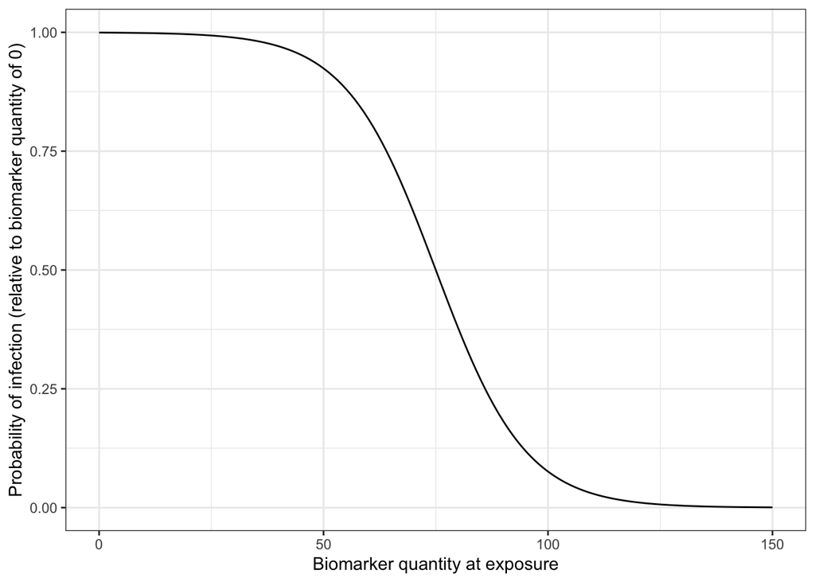

```r
## Specify immunity model within the runserosim function below
immunity_model<-immunity_model_vacc_ifxn_biomarker_prot

## Specify which exposure IDs represent vaccination events
## In this case, only exposure ID 3 is a vaccination event
vacc_exposures<-3

## Specify the time step after birth at which an individual is eligible for vaccination (2 months old for diphtheria and pertussis combine vaccine); ; note non-vaccine exposures are listed as NAs
vacc_age<-c(NA,NA,2)

## Specify the maximum number of successful exposure events an individual can receive for each exposure type
## We placed no successful exposure limit on the number of diphtheria or pertussis infection exposures and 3 dose limit on the vaccine exposure.
max_events<-c(Inf,Inf,3)

## Plot biomarker-mediated protection curve given parameters specified within model_pars for biomarker 1, diphtheria antibody  (DP_antibody) which will be loaded in section 1.6
## The immunity model we selected will take into account an individual's current titer to diphtheria when determining the probability of successful infection.
## Titers are ploted in mIU/mL
plot_biomarker_mediated_protection(0:150, biomarker_prot_midpoint=75, biomarker_prot_width=.1)
```

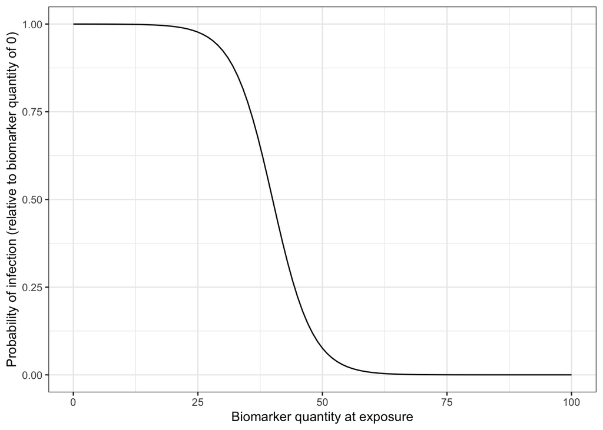

```r
## Plot biomarker-mediated protection curve given parameters specified within model_pars for biomarker 2, pertussis antibody (PT_antibody) which will be loaded in section 1.6
## The immunity model we selected will take into account an individual's current titer to pertussis when determining the probability of successful infection.
## Titers are ploted in IU/mL
plot_biomarker_mediated_protection(0:100, biomarker_prot_midpoint=40, biomarker_prot_width=.25)
```

# 1.6 Antibody model and model parameters

Now, we specify the antibody model to be used within *runserosim* to track antibody kinetics, or more broadly biomarker kinetics for each biomarker produced from successful exposure events. We will be using a biphasic boosting-waning model. This model assumes that for each exposure there is a set of long-term boost, long-term boost waning, short-term boost, and short-term boost waning parameters. Given varying diphtheria antibody dynamics observed in early and late life, we decided that a biphasic boosting-waning model was appropriate for our purposes (Voysey et al. 2016).

The antibody kinetics parameters needed for the antibody model are pre-loaded within a csv file which will take on the argument name: model_pars. Users can edit the csv file to modify any parameters. *runserosim* requires that exposure_id and biomarker_id are numeric within model_pars so we will use the reformat_biomarker_map function again to create a new version of model_pars. Users can go directly to numeric model_pars if they wish.

We selected a few diphtheria and pertussis serological surveys conducted which reported IgG titers following vaccination to inform the vaccine induced boost and waning parameters. There are many complexities and heterogeneity in these parameters which arise from different vaccine types and vaccination schedules. We neglect these complexities and select a few papers to give us some rough parameters for this example simulation.

After 3 vaccine doses, diphtheria titers ranged 1.5-1.7 IU/mL (Kimura et al. 1991) and pertussis titers above 100 IU/mL are associated with recent vaccination (“BORDG - Overview: Bordetella Pertussis Antibody, IgG, Serum,” n.d.). Diphtheria antibody half-life has been estimated to be around 19-27 years (Amanna, Carlson, and Slifka 2007; Hammarlund et al. 2016) with 10% of children losing immunity by one year following the primary vaccination series (Pichichero et al. 1987); 67% of children after 3 to 13 years and 83% after 14 to 23 years (Crossley et al. 1979). As for pertussis, the duration of immunity after a 3 dose series of the wP vaccine is estimated to be from 4 to 12 years (Sheridan et al. 2014). Pertussis titers >=100 IU/mL are associated with recent infection or vaccination within the past year while titers between 40 and 100 IU/mL are associated with recent infection (“BORDG - Overview: Bordetella Pertussis Antibody, IgG, Serum,” n.d.)

Our selected antibody kinetics parameters given our brief and limited literature search are as follows:

Diphtheria vaccine: Long term boost: 0.3-0.5 IU/mL Long term boost waning: 0.01 IU/mL per month Short term boost: 0.1-0.3 IU/mL Short term boost waning: 0.033 IU/mL per month

Pertussis vaccine: Long term boost: 30-50 IU/mL Long term boost waning: 0.0066 IU/mL per month Short term boost: 40-80 IU/mL Short term boost waning: 0.016 IU/mL per month

We were unable to find studies that reported titer kinetics following known infection events in comparable units. For simplicity, we will assume that natural infection boosting parameters are 25% higher than vaccine induced antibody boosting with similar waning rates.

Lastly, we define the draw_parameters function which determines how each individual’s antibody kinetics parameters are simulated from the within-host processes parameters tibble (model_pars). We will use a function which draws parameters directly from model_pars for the antibody model with random effects to represent individual heterogeneity in immunological responses. Parameters are drawn randomly from a distribution with mean and standard deviation specified within model_pars. This draw_parameters function also incorporates biomarker quantitiy dependent boosting (also known as titer-dependent boosting) where an individual’s realized boost is dependent on their titer level at the time of the exposure event.

We arbitrarily set the diphtheria titer-dependent boosting effects following an additional successful exposure event for individuals with diphtheria levels above 1.7 IU/mL to be only 10% of the full boost. Similarly, individuals with pertussis titers above 100 IU/mL will only receive 10% of the full boost for any additional successful exposure event.

```r
## Specify the antibody model
antibody_model<-antibody_model_biphasic

## Bring in the antibody parameters needed for the antibody model
## Note that the titer-mediated protection parameters needed for the immunity model, the titer-ceiling parameters needed for draw_parameters and the observation error parameter needed for the observation model are all defined here too.
## Also note that these are all arbitrary parameter values chosen for this toy example.
model_pars_path <- system.file("extdata", "model_pars_cs2.csv", package = "serosim")
model_pars_original <- read.csv(file = model_pars_path, header = TRUE)
model_pars_original
```

```
##    exposure_id biomarker_id                        name       mean    sd
## 1         vacc  DP_antibody                  boost_long   0.400000 1e-01
## 2         vacc  DP_antibody                 boost_short   0.200000 1e-01
## 3         vacc  DP_antibody                   wane_long   0.010000 5e-03
## 4         vacc  DP_antibody                  wane_short   0.033000 5e-03
## 5         vacc  DP_antibody biomarker_ceiling_threshold   1.700000    NA
## 6         vacc  DP_antibody  biomarker_ceiling_gradient   0.529411    NA
## 7         <NA>  DP_antibody                      obs_sd         NA 5e-02
## 8         vacc  PT_antibody                  boost_long  40.000000 1e+01
## 9         vacc  PT_antibody                 boost_short  60.000000 2e+01
## 10        vacc  PT_antibody                   wane_long   0.006600 5e-04
## 11        vacc  PT_antibody                  wane_short   0.016000 5e-04
## 12        vacc  PT_antibody biomarker_ceiling_threshold 100.000000    NA
## 13        vacc  PT_antibody  biomarker_ceiling_gradient   0.009000    NA
## 14        <NA>  PT_antibody                      obs_sd         NA 1e+01
```

[output cut: 47 more lines]

```r
## Reformat model_pars for runserosim
model_pars<-reformat_biomarker_map(model_pars_original)
model_pars
```

```
##    exposure_id biomarker_id                        name       mean    sd
## 1            3            1                  boost_long   0.400000 1e-01
## 2            3            1                 boost_short   0.200000 1e-01
## 3            3            1                   wane_long   0.010000 5e-03
## 4            3            1                  wane_short   0.033000 5e-03
## 5            3            1 biomarker_ceiling_threshold   1.700000    NA
## 6            3            1  biomarker_ceiling_gradient   0.529411    NA
## 7           NA            1                      obs_sd         NA 5e-02
## 8            3            2                  boost_long  40.000000 1e+01
## 9            3            2                 boost_short  60.000000 2e+01
## 10           3            2                   wane_long   0.006600 5e-04
## 11           3            2                  wane_short   0.016000 5e-04
## 12           3            2 biomarker_ceiling_threshold 100.000000    NA
## 13           3            2  biomarker_ceiling_gradient   0.009000    NA
## 14          NA            2                      obs_sd         NA 1e+01
```

[output cut: 47 more lines]

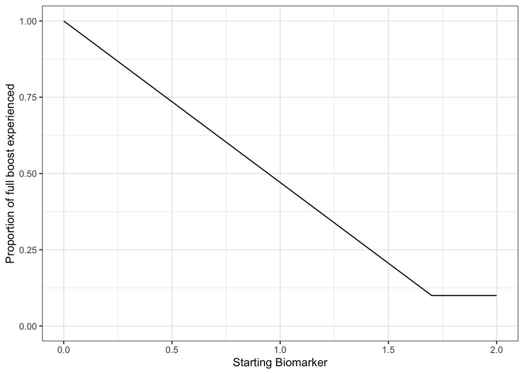

```r
## Specify the draw_parameters function to use
draw_parameters<-draw_parameters_random_fx_biomarker_dep

## Plot biomarker (in this case antibody titer) dependent boosting effects given parameters specified within model_pars for biomarker 1, diphtheria antibody (DP_antibody)
plot_biomarker_dependent_boosting(start=0, end=2, by=.1, biomarker_ceiling_threshold=1.7, biomarker_ceiling_gradient=0.529411)
```

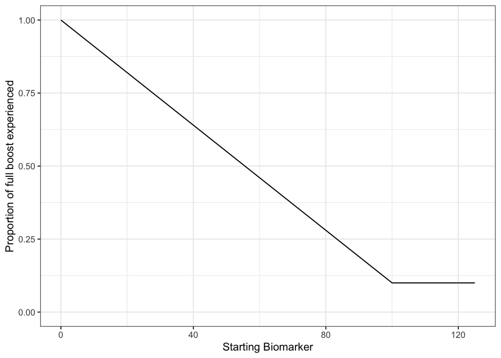

```r
## Plot biomarker (in this case antibody titer) dependent boosting effects given parameters specified within model_pars for biomarker 2, pertussis antibody (PT_antibody)
plot_biomarker_dependent_boosting(start=0, end=125, by=1, biomarker_ceiling_threshold=100, biomarker_ceiling_gradient=0.009)
```

[figure not shown]

```r
## Plot example biomarker trajectories given the specified antibody kinetics model, model parameters and draw parameters function
plot_antibody_model(antibody_model_biphasic, N=25, model_pars=model_pars,draw_parameters_fn = draw_parameters_random_fx_biomarker_dep, biomarker_map=biomarker_map)
```

# 1.7 Observation Model

Now we specify how observed biomarker quantities, in this case antibody titers, are generated as a probabilistic function of the true, latent biomarker quantities, and when to observe these quantities. In this step, users are specifying the sampling design and assay choice for their serological survey.

This observation model observes the latent titer values given a continuous assay with user-specified lower and upper limits, added noise. The added noise represents assay variability and is done by sampling from a distribution with the latent antibody titer as the mean and the measurement error as the standard deviation. The observation standard deviation and distribution is defined within model_pars as the “obs_sd” parameter for each biomarker.

Diphtheria: Lower limit of ELISA IgG Detectability: 0.01 IU/mL Upper limit of ELISA IgG Detectability: 2 IU/mL

Pertussis: Lower limit of ELISA IgG Detectability: 5 IU/mL Upper limit of ELISA IgG Detectability: 200 IU/mL

```r
## Specify the limits of detection for each biomarker for the continuous assays
bounds<-tibble(biomarker_id=c(1,1,2,2),name=rep(c("lower_bound","upper_bound"),2),value=c(0.01,2,5,200))

## Specify the observation model
observation_model<-observation_model_continuous_bounded_noise

## Specify observation_times to observe both biomarkers (aka DP_antibody and PT_antibody titers) across all individuals at the end of the simulation (t=120)
obs1 <- tibble(i=1:N,t=120, b=1)
obs2 <- tibble(i=1:N,t=120, b=2)
observation_times<-rbind(obs1,obs2)
```

# 1.8 Optional Arguments

There are no optional arguments needed for this simulation.

# 1.9 Run Simulation

This is the core simulation where all simulation settings, models and parameters are specified within the main simulation function. The run time for this step varies depending on the number of individuals and the complexities of the specified models. There is a built in pre-computation step within *runserosim* where the simulation attempts to perform as much pre-computation as possible for the exposure model to speed up the main simulation code. Users can turn off this pre-computation by setting pre-computation to FALSE within *runserosim*.

```r
res<- runserosim(
  simulation_settings,
  demography,
  observation_times,
  foe_pars,
  biomarker_map,
  model_pars,
  exposure_model,
  immunity_model,
  antibody_model,
  observation_model,
  draw_parameters,

  ## Other arguments needed
  bounds=bounds,
  max_events=max_events,
  vacc_exposures=vacc_exposures,
  vacc_age=vacc_age,
  dem_mod=dem_mod,
  t_in_year=t_in_year,
  VERBOSE=NULL,
  attempt_precomputation = FALSE
)
## Note that models and arguments specified earlier in the code can be specified directly within this function.
```

# 1.10 Generate Plots

Now that the simulation is complete, let’s plot and examine the simulation outputs.

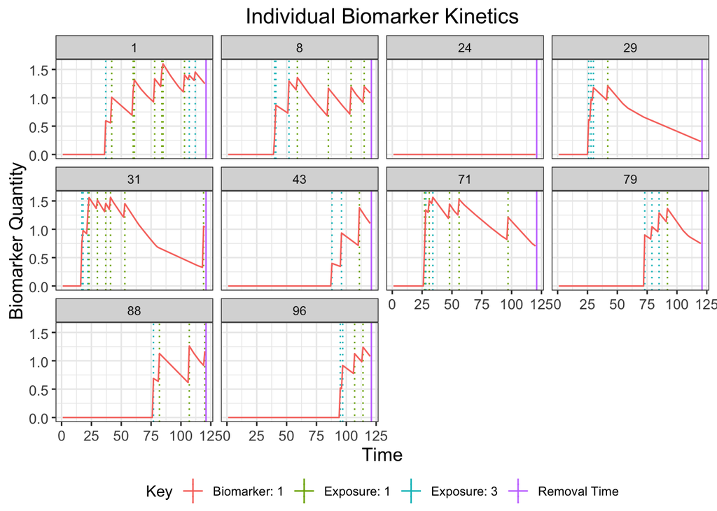

```r
## Plot diphtheria biomarker kinetics and exposure histories for 10 individuals
plot_subset_individuals_history(res$biomarker_states %>% filter(b==1), res$exposure_histories_long %>% filter(x==1 | x==3), subset=10, demography, removal=TRUE)
```

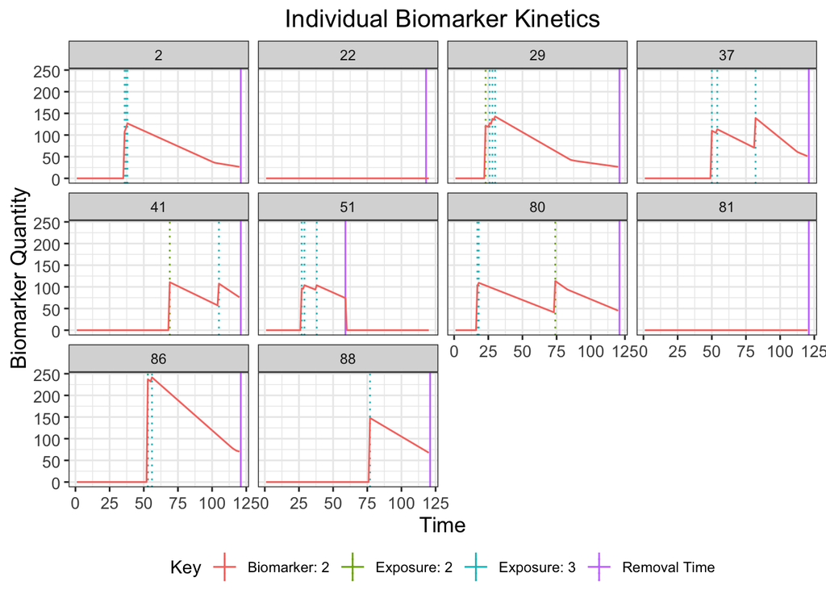

```r
## Plot pertussis biomarker kinetics and exposure histories for 10 individuals
plot_subset_individuals_history(res$biomarker_states %>% filter(b==2), res$exposure_histories_long %>% filter(x==2 | x==3), subset=10, demography, removal=TRUE)
```

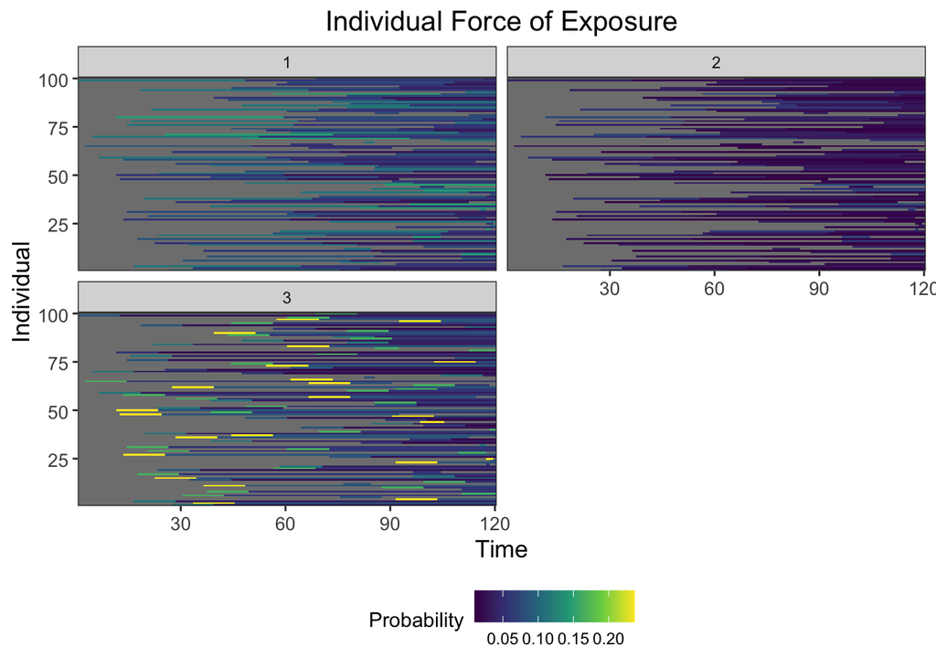

```r
## Plot individual probability of exposure for all exposure types.
## This is the output of the exposure model.
plot_exposure_force(res$exposure_force_long)
```

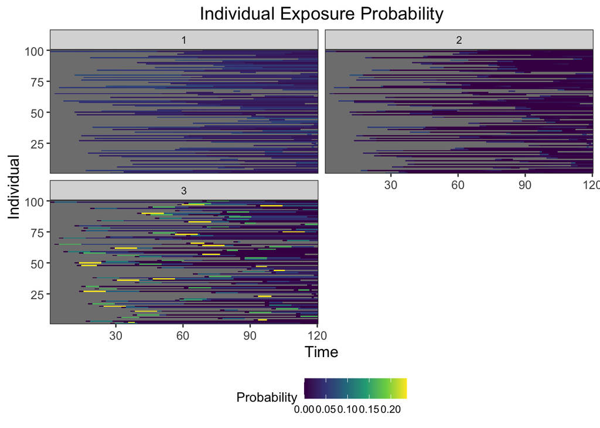

```r
## Plot individual successful exposure probabilities for all exposure types
## This is the output of the exposure model multiplied by the output of the immunity model.
## In other words, this is the probability of exposure event being successful and inducing an immunological response
plot_exposure_prob(res$exposure_probabilities_long)
```

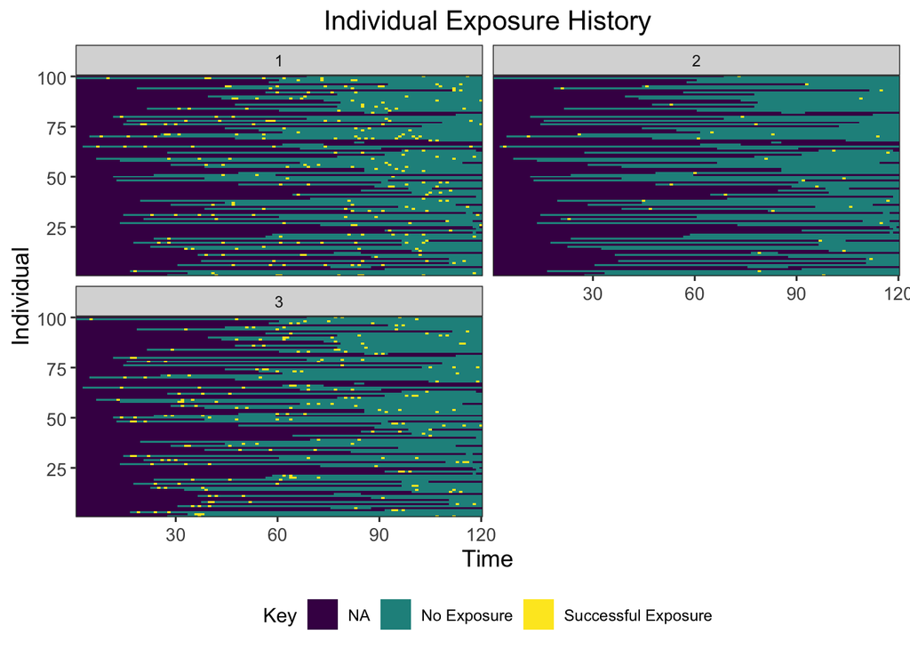

```r
## Plot individual exposure histories for all exposure types
plot_exposure_histories(res$exposure_histories_long)
```

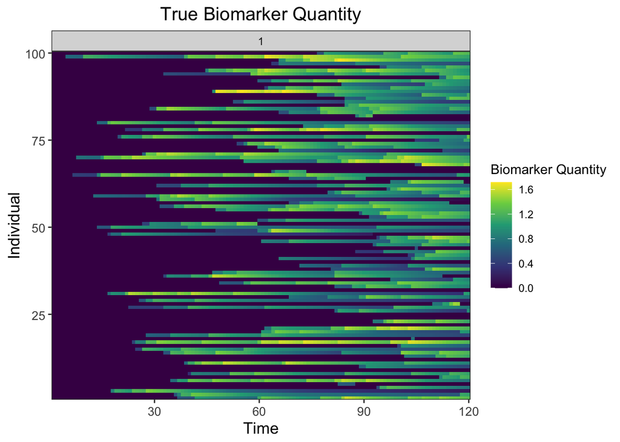

```r
## Plot diphtheria antibody (biomarker 1) states for all individuals (true biomarker quantities)
plot_biomarker_quantity(res$biomarker_states %>% filter(b==1))
```

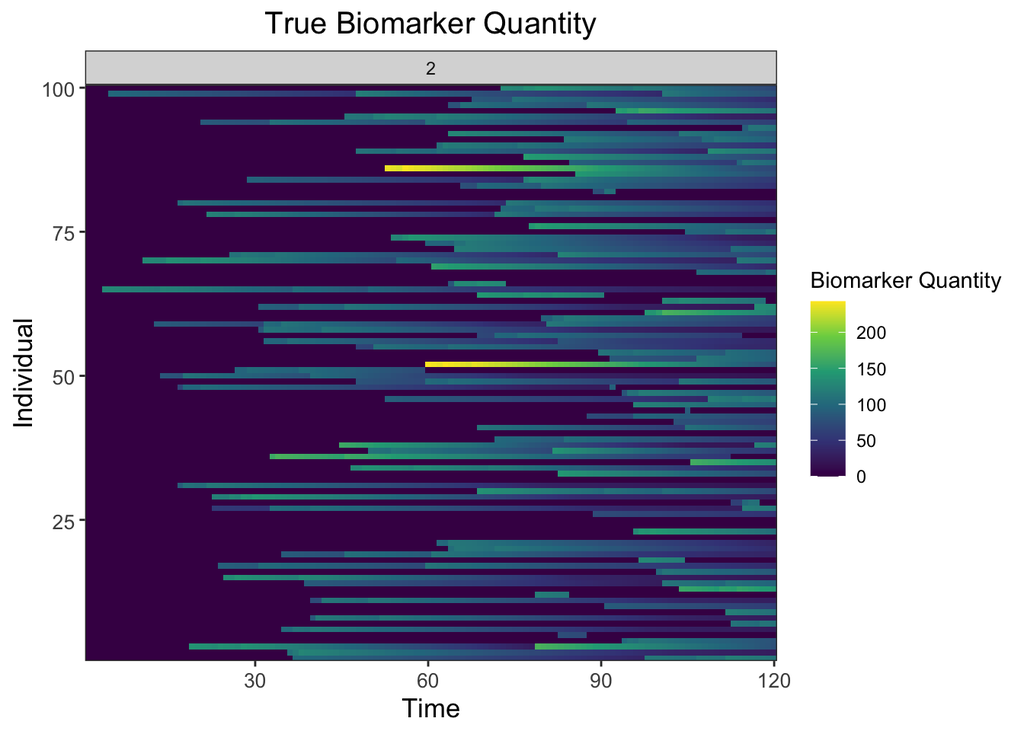

```r
## Plot pertussis antibody (biomarker 2) states for all individuals (true biomarker quantities)
plot_biomarker_quantity(res$biomarker_states %>% filter(b==2))
```

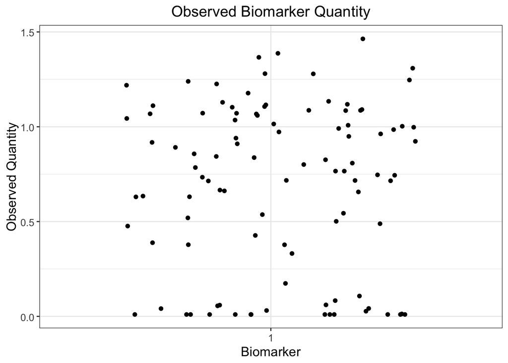

```r
## Plot the diphtheria serosurvey results (observed biomarker quantities)
plot_obs_biomarkers_one_sample(res$observed_biomarker_states %>% filter(b==1))
```

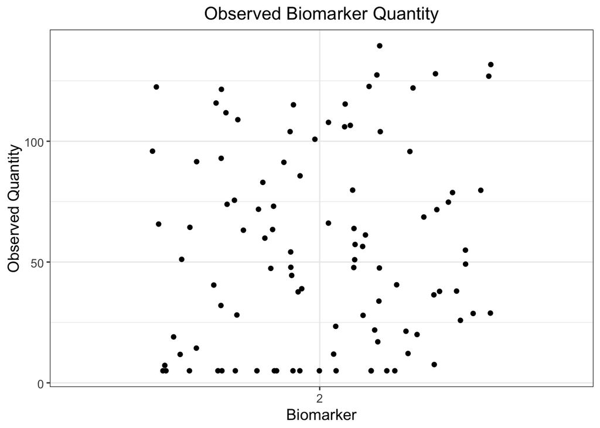

```r
## Plot the pertussis serosurvey results (observed biomarker quantities)
plot_obs_biomarkers_one_sample(res$observed_biomarker_states %>% filter(b==2))
```

```r
## Note that the simulated kinetics parameters are also stored
head(res$kinetics_parameters)
```

```
## # A tibble: 6 × 7
##       i     t     x     b name                          value realized_value
##   <int> <dbl> <dbl> <dbl> <chr>                         <dbl>          <dbl>
## 1     1    37     3     1 boost_long                  0.425          0.425
## 2     1    37     3     1 boost_short                 0.169          0.169
## 3     1    37     3     1 wane_long                   0.00706        0.00706
## 4     1    37     3     1 wane_short                  0.0337         0.0337
## 5     1    37     3     1 biomarker_ceiling_threshold 1.7            1.7
## 6     1    37     3     1 biomarker_ceiling_gradient  0.529          0.529
```

Amanna, Ian J, Nichole E Carlson, and Mark K Slifka. 2007. “Duration of Humoral Immunity to Common Viral and Vaccine Antigens.” *N. Engl. J. Med.* 357 (19): 1903–15.

Björkholm, B, M Böttiger, B Christenson, and L Hagberg. 1986. “Antitoxin Antibody Levels and the Outcome of Illness During an Outbreak of Diphtheria Among Alcoholics.” *Scand. J. Infect. Dis.* 18 (3): 235–39.

“BORDG - Overview: Bordetella Pertussis Antibody, IgG, Serum.” n.d. https://www.mayocliniclabs.com/test-catalog/overview/64780.

Chen, Zhiyun, Jing Zhang, Lina Cao, Nan Zhang, Junping Zhu, Guoling Ping, Jianhong Zhao, Shuming Li, and Qiushui He. 2016. “Seroprevalence of Pertussis Among Adults in China Where Whole Cell Vaccines Have Been Used for 50 Years.” *J. Infect.* 73 (1): 38–44.

Crossley, K, P Irvine, J B Warren, B K Lee, and K Mead. 1979. “Tetanus and Diphtheria Immunity in Urban Minnesota Adults.” *JAMA* 242 (21): 2298–2300.

Danilova, Elena, Pål A Jenum, Vegard Skogen, Valentin F Pilnikov, and Haakon Sjursen. 2006. “Antidiphtheria Antibody Responses in Patients and Carriers of Corynebacterium Diphtheriae in the Arkhangelsk Region of Russia.” *Clin. Vaccine Immunol.* 13 (6): 627–32.

Efstratiou, Androulla, Christopher P A Maple, and World Health Organization. Regional Office for Europe. 1994. “Laboratory Diagnosis of Diphtheria / by Androulla Efstratiou and p. A. Christopher Maple.” ICP/EPI 038(C). Copenhagen : WHO Regional Office for Europe.

Hammarlund, Erika, Archana Thomas, Elizabeth A Poore, Ian J Amanna, Abby E Rynko, Motomi Mori, Zunqiu Chen, and Mark K Slifka. 2016. “Durability of Vaccine-Induced Immunity Against Tetanus and Diphtheria Toxins: A Cross-Sectional Analysis.” *Clin. Infect. Dis.* 62 (9): 1111–18.

Ipsen, J. 1946. “Circulating Antitoxin at the Onset of Diphtheria in 425 Patients.” *J. Immunol.* 54 (4): 325–47.

Kimura, M, H Kuno-Sakai, Y Sato, H Kamiya, R Nii, S Isomura, K Horiuchi, T Kato, M Deguchi, and H Saikusa. 1991. “A Comparative Trial of the Reactogenicity and Immunogenicity of Takeda Acellular Pertussis Vaccine Combined with Tetanus and Diphtheria Toxoids. Outcome in 3- to 8-Month-Old Infants, 9- to 23-Month-Old Infants and Children, and 24- to 30-Month-Old Children.” *Am. J. Dis. Child.* 145 (7): 734–41.

Ohuabunwo, Chima, Jurijs Perevoscikovs, Aija Griskevica, Paul Gargiullo, Anita Brilla, Ludmila Viksna, Steffen Glismann, Melinda Wharton, and Charles Vitek. 2005. “Respiratory Diphtheria Among Highly Vaccinated Military Trainees in Latvia: Improved Protection from DT Compared with Td Booster Vaccination.” *Scand. J. Infect. Dis.* 37 (11-12): 813–20.

Pichichero, Michael E, Thomas J Badgett, George C Rodgers Jr, Samuel Mclinn, Blanca Trevino-Scatterday, and John D Nelson. 1987. “Acellular Pertussis Vaccine: Immunogenicity and Safety of an Acellular Pertussisvs.a Whole Cell Pertussis Vaccine Combined with Diphtheria and Tetanus Toxoids as a Booster in 18- to 24-Month Old Children.” *Pediatr. Infect. Dis. J.* 6 (4): 352.

Plotkin, Stanley A. 2008. “Vaccines: Correlates of Vaccine-Induced Immunity.” *Clin. Infect. Dis.* 47 (3): 401–9.

Razafimahatratra, Solohery L, Arthur Menezes, Amy Wesolowski, Lala Rafetrarivony, Simon Cauchemez, Richter Razafindratsimandresy, Aina Harimanana, Tania Crucitti, Jean Marc Collard, and C J E Metcalf. 2022. “Leveraging Serology to Titrate Immunisation Programme Functionality for Diphtheria in Madagascar.” *Epidemiology & Infection* 150.

Saso, Anja, and Beate Kampmann. 2020. “Maternal Immunization: Nature Meets Nurture.” *Front. Microbiol.* 11 (July): 1499.

Sheridan, Sarah L, Katie Frith, Thomas L Snelling, Keith Grimwood, Peter B McIntyre, and Stephen B Lambert. 2014. “Waning Vaccine Immunity in Teenagers Primed with Whole Cell and Acellular Pertussis Vaccine: Recent Epidemiology.” *Expert Rev. Vaccines* 13 (9): 1081–1106.

Storsaeter, Jann, Hans O Hallander, Lennart Gustafsson, and Patrick Olin. 2003. “Low Levels of Antipertussis Antibodies Plus Lack of History of Pertussis Correlate with Susceptibility After Household Exposure to Bordetella Pertussis.” *Vaccine* 21 (25-26): 3542–49.

Voysey, Merryn, Rama Kandasamy, Ly-Mee Yu, Martine Baudin, Christine Sadorge, Stéphane Thomas, Tessa John, and Andrew J Pollard. 2016. “The Predicted Persistence and Kinetics of Antibody Decline 9years After Pre-School Booster Vaccination in UK Children.” *Vaccine* 34 (35): 4221–28.

World Health Organization. 2017. “Review of Evidence on Vaccine Effectiveness and Immunogenicity to Assess the Duration of Protection $\geq$10 Years After the Last Booster Dose.”